# CustomerSegmentation_TestData_PreProcessing

```python
import numpy as np, pandas as pd
import seaborn as sns
import matplotlib
import matplotlib.pyplot as plt
from datetime import datetime
import warnings
warnings.filterwarnings("ignore")
```

```python
import os
os.getcwd()
```

```
'C:\\Users\\Prateek\\Documents\\InsofeEdu\\SCTExams\\PHD\\Work_Python'
```

```python
new_Customers_Txns = pd.read_csv('C:/Users/Prateek/Documents/InsofeEdu/SCTExams/PHD/TestData/NewCustomerTransactions_Segmentation.csv')
```

```python
new_Customers_Txns.head(1)
```

|  | BillNumber | BillDate | CustomerID | ProductID | ProductCategory | Sales | Quantity |
| --- | --- | --- | --- | --- | --- | --- | --- |
| 0 | B38262 | 2014-09-19 | C21116 | PR7012 | Office Supplies | 5.67 | 3 |

```python
new_Customers = pd.read_csv('C:/Users/Prateek/Documents/InsofeEdu/SCTExams/PHD/TestData/NewCustomerDemographics_Segmentation.csv')
new_Customers.head(1)
```

|  | CustomerID | DOB | gender | MaritalStatus | Familysize |
| --- | --- | --- | --- | --- | --- |
| 0 | C21116 | 1973-11-21 | M | Yes | 4 |

```python
new_Customers['Familysize'] = new_Customers['Familysize'].astype('category')
```

```python
new_Customers.dtypes
```

```
CustomerID         object
DOB                object
gender             object
MaritalStatus      object
Familysize       category
dtype: object
```

```python
new_Customers[new_Customers.select_dtypes(['object']).columns] = new_Customers.select_dtypes(['object']).apply(lambda x: x.astype('category'))
new_Customers.dtypes
```

```
CustomerID       category
DOB              category
gender           category
MaritalStatus    category
Familysize       category
dtype: object
```

```python
new_Customers.shape
```

```
(500, 5)
```

```python
new_Customers_Txns.shape
```

```
(6220, 7)
```

```python
new_Customers_Txns.dtypes
```

```
BillNumber          object
BillDate            object
CustomerID          object
ProductID           object
ProductCategory     object
Sales              float64
Quantity             int64
dtype: object
```

```python
new_Customers_Txns[new_Customers_Txns.select_dtypes(['object']).columns] = new_Customers_Txns.select_dtypes(['object']).apply(lambda x: x.astype('category'))
new_Customers_Txns.dtypes
```

```
BillNumber         category
BillDate           category
CustomerID         category
ProductID          category
ProductCategory    category
Sales               float64
Quantity              int64
dtype: object
```

```python
len(pd.unique(new_Customers['CustomerID']))
```

```
500
```

```python
len(pd.unique(new_Customers_Txns['CustomerID']))
```

```
500
```

```python
new_Customers.isna().sum()
```

```
CustomerID       0
DOB              0
gender           0
MaritalStatus    0
Familysize       0
dtype: int64
```

```python
new_Customers_Txns.isna().sum()
```

```
BillNumber         0
BillDate           0
CustomerID         0
ProductID          0
ProductCategory    0
Sales              0
Quantity           0
dtype: int64
```

```python
new_Customers_Txns.isnull().sum()
```

```
BillNumber         0
BillDate           0
CustomerID         0
ProductID          0
ProductCategory    0
Sales              0
Quantity           0
dtype: int64
```

#### Since, all customers present in transaction table are from training Demographic data, and there are no 'Unknown' customers in transactions training data.

#### Can proceed with 'inner-join'.

```python
new_Customer_Txn_Data = pd.merge(new_Customers, new_Customers_Txns, on='CustomerID')
new_Customer_Txn_Data.shape
```

```
(6220, 11)
```

```python
new_Customer_Txn_Data.head()
```

|  | CustomerID | DOB | gender | MaritalStatus | Familysize | BillNumber | BillDate | ProductID | ProductCategory | Sales | Quantity |
| --- | --- | --- | --- | --- | --- | --- | --- | --- | --- | --- | --- |
| 0 | C21116 | 1973-11-21 | M | Yes | 4 | B38262 | 2014-09-19 | PR7012 | Office Supplies | 5.670 | 3 |
| 1 | C21116 | 1973-11-21 | M | Yes | 4 | B38128 | 2014-09-23 | PR7313 | Office Supplies | 28.800 | 9 |
| 2 | C21116 | 1973-11-21 | M | Yes | 4 | B42017 | 2015-03-16 | PR6640 | Office Supplies | 17.520 | 3 |
| 3 | C21116 | 1973-11-21 | M | Yes | 4 | B39125 | 2015-04-29 | PR7219 | Office Supplies | 7.968 | 2 |
| 4 | C21116 | 1973-11-21 | M | Yes | 4 | B38809 | 2015-12-11 | PR6925 | Office Supplies | 110.528 | 4 |

```python
new_Customer_Txn_Data.isna().sum()
```

```
CustomerID         0
DOB                0
gender             0
MaritalStatus      0
Familysize         0
BillNumber         0
BillDate           0
ProductID          0
ProductCategory    0
Sales              0
Quantity           0
dtype: int64
```

```python
new_Customer_Txn_Data.describe(include='all').transpose()
```

|  | count | unique | top | freq | mean | std | min | 25% | 50% | 75% | max |
| --- | --- | --- | --- | --- | --- | --- | --- | --- | --- | --- | --- |
| CustomerID | 6220 | 500 | C21344 | 34 | NaN | NaN | NaN | NaN | NaN | NaN | NaN |
| DOB | 6220 | 496 | 1998-09-08 | 34 | NaN | NaN | NaN | NaN | NaN | NaN | NaN |
| gender | 6220 | 2 | F | 3364 | NaN | NaN | NaN | NaN | NaN | NaN | NaN |
| MaritalStatus | 6220 | 2 | Yes | 5956 | NaN | NaN | NaN | NaN | NaN | NaN | NaN |
| Familysize | 6220 | 4 | 4 | 4180 | NaN | NaN | NaN | NaN | NaN | NaN | NaN |
| BillNumber | 6220 | 3108 | B41514 | 12 | NaN | NaN | NaN | NaN | NaN | NaN | NaN |
| BillDate | 6220 | 1032 | 2014-09-07 | 33 | NaN | NaN | NaN | NaN | NaN | NaN | NaN |
| ProductID | 6220 | 1727 | PR6407 | 16 | NaN | NaN | NaN | NaN | NaN | NaN | NaN |
| ProductCategory | 6220 | 3 | Office Supplies | 3752 | NaN | NaN | NaN | NaN | NaN | NaN | NaN |
| Sales | 6220 | NaN | NaN | NaN | 224.689 | 661.119 | 0.984 | 17.748 | 55.6 | 209.974 | 22638.5 |
| Quantity | 6220 | NaN | NaN | NaN | 3.78794 | 2.20625 | 1 | 2 | 3 | 5 | 14 |

### Understanding Basic stats : Covariance and Correlation.

```python
new_Customer_Txn_Data.corr()  # Same as Train DATA
```

|  | Sales | Quantity |
| --- | --- | --- |
| Sales | 1.000000 | 0.177275 |
| Quantity | 0.177275 | 1.000000 |

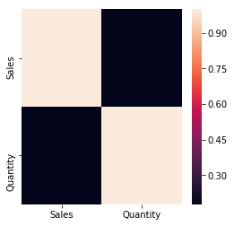

```python
plt.figure(figsize= (4,4))
sns.heatmap(new_Customer_Txn_Data.corr())
plt.show()
```

```python
new_Customer_Txn_Data.cov() # 278 in train (vs) 258 in test
```

|  | Sales | Quantity |
| --- | --- | --- |
| Sales | 437078.289226 | 258.572224 |
| Quantity | 258.572224 | 4.867550 |

### Visualizing DATA and understanding the spread or variables.

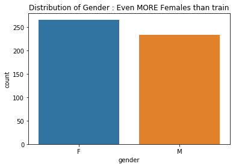

```python
# See the distribution of gender to recognize different distributions
sns.countplot(x='gender', data=new_Customers);
plt.title('Distribution of Gender : Even MORE Females than train');
```

```python
Gender_Marriage = pd.crosstab(new_Customer_Txn_Data['gender'], new_Customer_Txn_Data['MaritalStatus'])
Gender_Marriage
```

| MaritalStatus gender | No | Yes |
| --- | --- | --- |
| M | 114 | 2742 |
| F | 150 | 3214 |

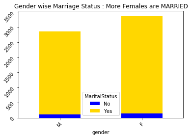

```python
Gender_Marriage.plot(kind='bar', stacked=True, color=['blue','gold'], grid=False)
plt.title('Gender wise Marriage Status : More Females are MARRIED')
plt.xticks(rotation = 50)
plt.yticks(rotation = 50)
plt.show()
```

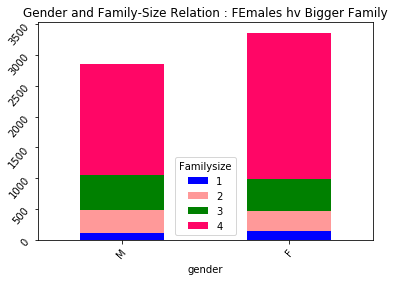

```python
Gender_Family = pd.crosstab(new_Customer_Txn_Data['gender'], new_Customer_Txn_Data['Familysize'])
Gender_Family.plot(kind='bar', stacked=True, color=['blue','#FF9999', 'green','#FF0666'], grid=False)
plt.title('Gender and Family-Size Relation : FEmales hv Bigger Family')
plt.xticks(rotation = 50)
plt.yticks(rotation = 50)
plt.show()
```

```python
Gender_Family
```

| Familysize gender | 1 | 2 | 3 | 4 |
| --- | --- | --- | --- | --- |
| M | 114 | 377 | 562 | 1803 |
| F | 150 | 324 | 513 | 2377 |

```python
Marriage_Family = pd.crosstab(new_Customer_Txn_Data['MaritalStatus'], new_Customer_Txn_Data['Familysize'])
Marriage_Family
```

| Familysize MaritalStatus | 1 | 2 | 3 | 4 |
| --- | --- | --- | --- | --- |
| Yes | 0 | 701 | 1075 | 4180 |
| No | 264 | 0 | 0 | 0 |

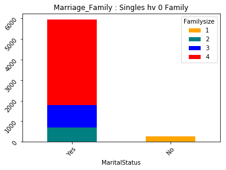

```python
Marriage_Family.plot(kind='bar', stacked=True, color=['orange','teal', 'blue','red'], grid=False)
plt.title('Marriage_Family : Singles hv 0 Family')
plt.xticks(rotation = 50)
plt.yticks(rotation = 50)
plt.show()
```

```python
Gender_PurchaseCatg = pd.crosstab(new_Customer_Txn_Data['gender'], new_Customer_Txn_Data['ProductCategory'])
Gender_PurchaseCatg
```

| ProductCategory gender | Furniture | Office Supplies | Technology |
| --- | --- | --- | --- |
| M | 591 | 1751 | 514 |
| F | 743 | 2001 | 620 |

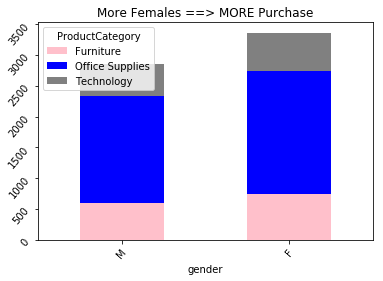

```python
Gender_PurchaseCatg.plot(kind='bar', stacked=True, color=['pink','blue', 'grey'], grid=False)
plt.title('More Females ==> MORE Purchase')
plt.xticks(rotation = 50)
plt.yticks(rotation = 50)
plt.show()
```

```python
MarriedPplPurchase = pd.crosstab(new_Customer_Txn_Data['MaritalStatus'], new_Customer_Txn_Data['ProductCategory'])
MarriedPplPurchase
```

| ProductCategory MaritalStatus | Furniture | Office Supplies | Technology |
| --- | --- | --- | --- |
| Yes | 1274 | 3591 | 1091 |
| No | 60 | 161 | 43 |

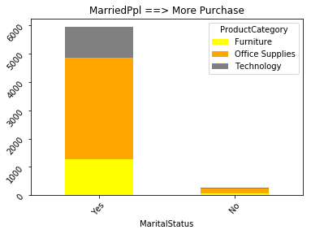

```python
MarriedPplPurchase.plot(kind='bar', stacked=True, color=['yellow','orange', 'grey'], grid=False)
plt.title('MarriedPpl ==> More Purchase')
plt.xticks(rotation = 50)
plt.yticks(rotation = 50)
plt.show()
```

#### An estimate of the underlying "true" distribution, therefore it is smoothed into a continuous line plot.

```
Text(0.5,1,'KDE : Sales in 4 years')
```

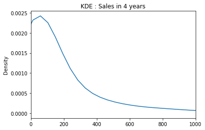

```python
new_Customer_Txn_Data['Sales'].plot(kind='kde', xlim=(0,1000))
plt.title('KDE : Sales in 4 years')
```

```
Text(0.5,1,'KDE : Quantities Sold in 4 years')
```

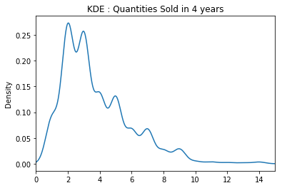

```python
new_Customer_Txn_Data['Quantity'].plot(kind='kde', xlim=(0,15))
plt.title('KDE : Quantities Sold in 4 years')
```

## Boxplots

Display of common quantiles : the quartiles and the lower and upper 5 percent values.

##### Data is densly populated, so to see better boxplot, scale the axes

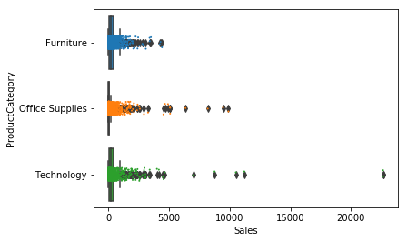

```python
sns.boxplot(data = new_Customer_Txn_Data, x='Sales', y = 'ProductCategory')
sns.stripplot(data =new_Customer_Txn_Data, x='Sales', y = 'ProductCategory', jitter=True, edgecolor='gray', size=2)
```

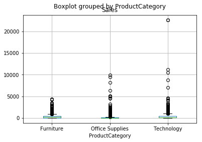

```python
new_Customer_Txn_Data.boxplot(column='Sales', by='ProductCategory', grid=True)
```

#### Feature Engineer : Bill-Date into Day, Month and Year.

```python
new_Customer_Txn_Data.head()
```

|  | CustomerID | DOB | gender | MaritalStatus | Familysize | BillNumber | BillDate | ProductID | ProductCategory | Sales | Quantity |
| --- | --- | --- | --- | --- | --- | --- | --- | --- | --- | --- | --- |
| 0 | C21116 | 1973-11-21 | M | Yes | 4 | B38262 | 2014-09-19 | PR7012 | Office Supplies | 5.670 | 3 |
| 1 | C21116 | 1973-11-21 | M | Yes | 4 | B38128 | 2014-09-23 | PR7313 | Office Supplies | 28.800 | 9 |
| 2 | C21116 | 1973-11-21 | M | Yes | 4 | B42017 | 2015-03-16 | PR6640 | Office Supplies | 17.520 | 3 |
| 3 | C21116 | 1973-11-21 | M | Yes | 4 | B39125 | 2015-04-29 | PR7219 | Office Supplies | 7.968 | 2 |
| 4 | C21116 | 1973-11-21 | M | Yes | 4 | B38809 | 2015-12-11 | PR6925 | Office Supplies | 110.528 | 4 |

```python
# Extraction Patterns:

year = lambda x: datetime.strptime(x, "%Y-%m-%d" ).year

day_of_month = lambda x: datetime.strptime(x, "%Y-%m-%d").day

week_of_year = lambda x: pd.to_datetime(datetime.strptime(x, "%Y-%m-%d")).week

month = lambda x: datetime.strptime(x, "%Y-%m-%d").month
```

```python
# Customer BirthDay Month
new_Customer_Txn_Data['Customer_BirthDay_Month'] = new_Customer_Txn_Data['DOB'].map(month)
# Bill Date Related
new_Customer_Txn_Data['Bill_Year'] = new_Customer_Txn_Data['BillDate'].map(year)
new_Customer_Txn_Data['Bill_Month'] = new_Customer_Txn_Data['BillDate'].map(month)
new_Customer_Txn_Data['Bill_Day'] = new_Customer_Txn_Data['BillDate'].map(day_of_month)
new_Customer_Txn_Data['Bill_Week_of_Year'] = new_Customer_Txn_Data['BillDate'].map(week_of_year)
```

# Feature Engineer - Customer_Age

```python
import dateutil

def birthday(date):
    # Get the current date
    now = datetime.utcnow()
    now = now.date()

    # Get the difference between the current date and the birthday
    age = dateutil.relativedelta.relativedelta(now, date)
    age = age.years

    return age
```

```python
new_Customer_Txn_Data['DOB'] = pd.to_datetime(new_Customer_Txn_Data['DOB'])
```

```python
new_Customer_Txn_Data['Customer_Age'] = new_Customer_Txn_Data['DOB'].apply(lambda x : birthday(x))
```

```python
new_Customer_Txn_Data.info()
```

```
<class 'pandas.core.frame.DataFrame'>
Int64Index: 6220 entries, 0 to 6219
Data columns (total 17 columns):
CustomerID                 6220 non-null category
DOB                        6220 non-null datetime64[ns]
gender                     6220 non-null category
MaritalStatus              6220 non-null category
Familysize                 6220 non-null category
BillNumber                 6220 non-null category
BillDate                   6220 non-null category
ProductID                  6220 non-null category
ProductCategory            6220 non-null category
Sales                      6220 non-null float64
Quantity                   6220 non-null int64
Customer_BirthDay_Month    6220 non-null int64
Bill_Year                  6220 non-null int64
Bill_Month                 6220 non-null int64
Bill_Day                   6220 non-null int64
Bill_Week_of_Year          6220 non-null int64
Customer_Age               6220 non-null int64
dtypes: category(8), datetime64[ns](1), float64(1), int64(7)
memory usage: 989.0 KB
```

```python
new_Customer_Txn_Data.describe(include='all').transpose()
```

|  | count | unique | top | freq | first | last | mean | std | min | 25% | 50% | 75% | max |
| --- | --- | --- | --- | --- | --- | --- | --- | --- | --- | --- | --- | --- | --- |
| CustomerID | 6220 | 500 | C21344 | 34 | NaN | NaN | NaN | NaN | NaN | NaN | NaN | NaN | NaN |
| DOB | 6220 | 496 | 1998-09-08 00:00:00 | 34 | 1933-04-04 00:00:00 | 2000-08-19 00:00:00 | NaN | NaN | NaN | NaN | NaN | NaN | NaN |
| gender | 6220 | 2 | F | 3364 | NaN | NaN | NaN | NaN | NaN | NaN | NaN | NaN | NaN |
| MaritalStatus | 6220 | 2 | Yes | 5956 | NaN | NaN | NaN | NaN | NaN | NaN | NaN | NaN | NaN |
| Familysize | 6220 | 4 | 4 | 4180 | NaN | NaN | NaN | NaN | NaN | NaN | NaN | NaN | NaN |
| BillNumber | 6220 | 3108 | B41514 | 12 | NaN | NaN | NaN | NaN | NaN | NaN | NaN | NaN | NaN |
| BillDate | 6220 | 1032 | 2014-09-07 | 33 | NaN | NaN | NaN | NaN | NaN | NaN | NaN | NaN | NaN |
| ProductID | 6220 | 1727 | PR6407 | 16 | NaN | NaN | NaN | NaN | NaN | NaN | NaN | NaN | NaN |
| ProductCategory | 6220 | 3 | Office Supplies | 3752 | NaN | NaN | NaN | NaN | NaN | NaN | NaN | NaN | NaN |
| Sales | 6220 | NaN | NaN | NaN | NaN | NaN | 224.689 | 661.119 | 0.984 | 17.748 | 55.6 | 209.974 | 22638.5 |
| Quantity | 6220 | NaN | NaN | NaN | NaN | NaN | 3.78794 | 2.20625 | 1 | 2 | 3 | 5 | 14 |
| Customer_BirthDay_Month | 6220 | NaN | NaN | NaN | NaN | NaN | 6.30772 | 3.49564 | 1 | 3 | 6 | 9 | 12 |
| Bill_Year | 6220 | NaN | NaN | NaN | NaN | NaN | 2015.71 | 1.13228 | 2014 | 2015 | 2016 | 2017 | 2017 |
| Bill_Month | 6220 | NaN | NaN | NaN | NaN | NaN | 7.81768 | 3.26759 | 1 | 5 | 9 | 11 | 12 |
| Bill_Day | 6220 | NaN | NaN | NaN | NaN | NaN | 15.5336 | 8.75507 | 1 | 8 | 16 | 23 | 31 |
| Bill_Week_of_Year | 6220 | NaN | NaN | NaN | NaN | NaN | 32.1006 | 14.2606 | 1 | 21 | 35 | 45 | 53 |
| Customer_Age | 6220 | NaN | NaN | NaN | NaN | NaN | 41.1096 | 16.619 | 18 | 28 | 38 | 49 | 85 |

```python
new_Customer_Txn_Data.shape
```

```
(6220, 17)
```

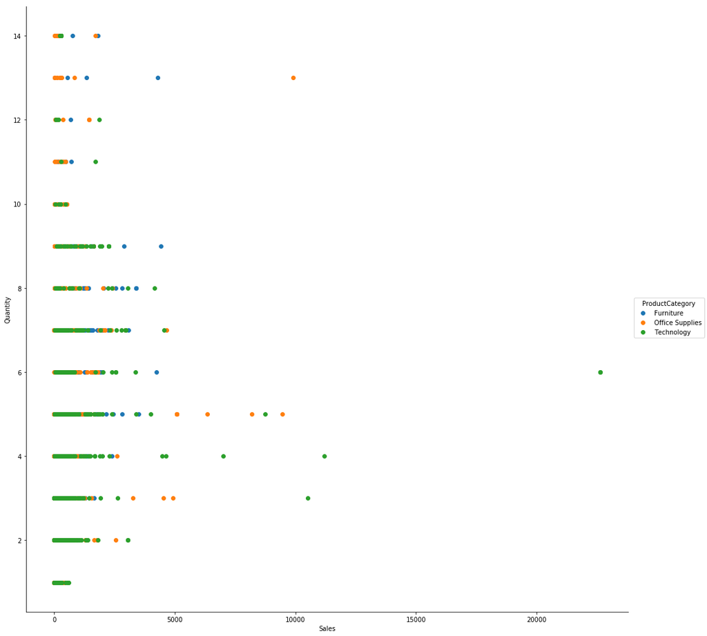

```python
sns.FacetGrid(new_Customer_Txn_Data, hue='ProductCategory',
              size = 14).map(plt.scatter,
                             'Sales',
                             'Quantity').add_legend()
#sns.stripplot(data =customer_Txn_Data, x='Sales', y = 'Quantity', jitter=True, edgecolor='gray', size=2)
```

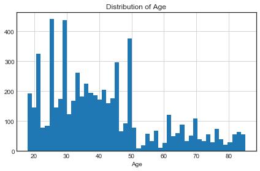

```python
# Histogram of ages
plt.style.use('seaborn-white');
new_Customer_Txn_Data.hist('Customer_Age', bins=50);
plt.title('Distribution of Age');
plt.xlabel('Age');
plt.tight_layout();
```

```
Text(0,0.5,'Sales')
```

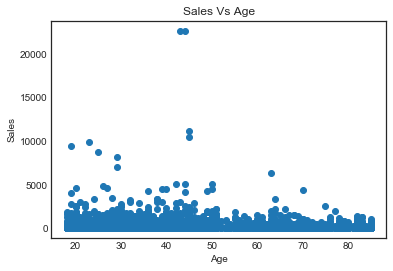

```python
# Scatter Plot
plt.scatter(new_Customer_Txn_Data['Customer_Age'],new_Customer_Txn_Data['Sales'])
plt.title('Sales Vs Age')
plt.xlabel('Age')
plt.ylabel('Sales')
#plt.xlim(0, 500)
#plt.ylim(0, 2000)
```

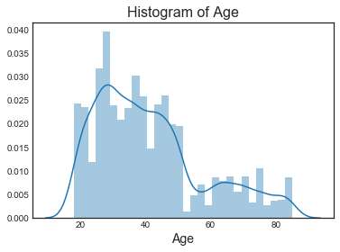

```python
plt.figure(figsize = (6,4))
b = sns.distplot(new_Customer_Txn_Data.Customer_Age)
b.set_title('Histogram of Age',fontsize = 16)
b.set_xlabel("Age",fontsize=14)
plt.show()
```

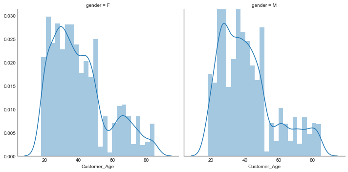

```python
g = sns.FacetGrid(new_Customer_Txn_Data,col='gender',size = 5)
g.map(sns.distplot,'Customer_Age')
plt.show()
```

#### Verifying if simple [Sales] / [Quantity] can be done

```python
new_Customer_Txn_Data['Product_Unit_Price']=new_Customer_Txn_Data['Sales']/new_Customer_Txn_Data['Quantity']
new_Customer_Txn_Data.head(2)
```

|  | CustomerID | DOB | gender | MaritalStatus | Familysize | BillNumber | BillDate | ProductID | ProductCategory | Sales | Quantity | Customer_BirthDay_Month | Bill_Year | Bill_Month | Bill_Day | Bill_Week_of_Year | Customer_Age | Product_Unit_Price |
| --- | --- | --- | --- | --- | --- | --- | --- | --- | --- | --- | --- | --- | --- | --- | --- | --- | --- | --- |
| 0 | C21116 | 1973-11-21 | M | Yes | 4 | B38262 | 2014-09-19 | PR7012 | Office Supplies | 5.67 | 3 | 11 | 2014 | 9 | 19 | 38 | 45 | 1.89 |
| 1 | C21116 | 1973-11-21 | M | Yes | 4 | B38128 | 2014-09-23 | PR7313 | Office Supplies | 28.80 | 9 | 11 | 2014 | 9 | 23 | 39 | 45 | 3.20 |

```
matplotlib.patches.Circle
```

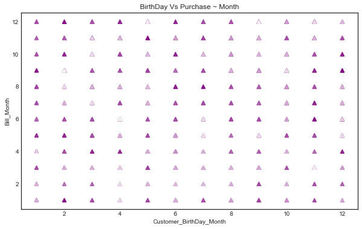

```python
# Plotting Customer BirthDay Month and His Purchase month for each record:
plt.figure(figsize = (10,6))   # How big is the plot ~ overall scale
# Scatter Plot
plt.scatter(new_Customer_Txn_Data['Customer_BirthDay_Month'],
            new_Customer_Txn_Data['Bill_Month'],
            c = ['white', 'purple'],
           marker = '^',
           alpha = 0.5)
plt.title('BirthDay Vs Purchase ~ Month')
plt.xlabel('Customer_BirthDay_Month')
plt.ylabel('Bill_Month')
plt.Circle
#plt.xlim(0, 36)  # Tells the lenght of X-Axis
#plt.ylim(0, 36)   # Tells the lenght of Y-Axis
```

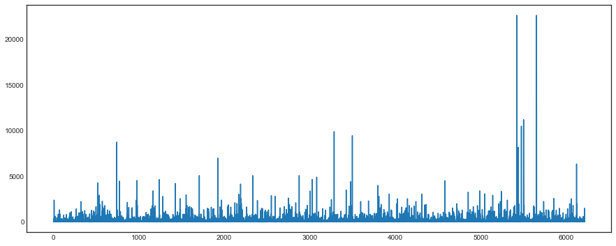

```python
new_Customer_Txn_Data['Sales'].plot(figsize=(15, 6))
plt.show()
```

### Correlation

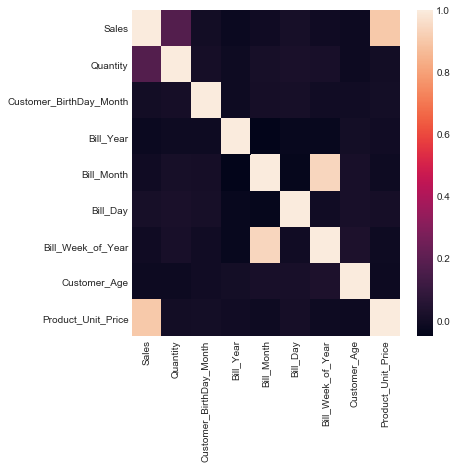

```python
plt.figure(figsize= (6,6))
sns.heatmap(new_Customer_Txn_Data.corr())
plt.show()
```

### Getting VIF values for the above correlation plot

```python
X2 = new_Customer_Txn_Data.loc[:,['Sales','Quantity','Product_Unit_Price','Customer_BirthDay_Month','Bill_Year','Bill_Month','Bill_Day','Bill_Week_of_Year','Customer_Age']]
X2.dtypes
```

```
Sales                      float64
Quantity                     int64
Product_Unit_Price         float64
Customer_BirthDay_Month      int64
Bill_Year                    int64
Bill_Month                   int64
Bill_Day                     int64
Bill_Week_of_Year            int64
Customer_Age                 int64
dtype: object
```

```python
from statsmodels.stats.outliers_influence import variance_inflation_factor
from statsmodels.tools.tools import add_constant
X1=add_constant(X2)
pd.Series([variance_inflation_factor(X1.values, i) for i in range(X1.shape[1])], index=X1.columns)
```

```
const                      3.199475e+06
Sales                      6.560268e+00
Quantity                   1.210454e+00
Product_Unit_Price         6.351866e+00
Customer_BirthDay_Month    1.001649e+00
Bill_Year                  1.009177e+00
Bill_Month                 8.640204e+00
Bill_Day                   1.011734e+00
Bill_Week_of_Year          8.618815e+00
Customer_Age               1.002743e+00
dtype: float64
```

This is same as train data.

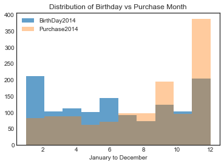

```python
# Histogram of income by gender
plt.hist('Customer_BirthDay_Month', data=new_Customer_Txn_Data[new_Customer_Txn_Data['Bill_Year'] == 2014], alpha=0.7, label='BirthDay2014');
plt.hist('Bill_Month', data=new_Customer_Txn_Data[new_Customer_Txn_Data['Bill_Year'] == 2014], alpha=0.4, label='Purchase2014');
plt.title('Distribution of Birthday vs Purchase Month');
plt.xlabel('January to December');
plt.legend();
```

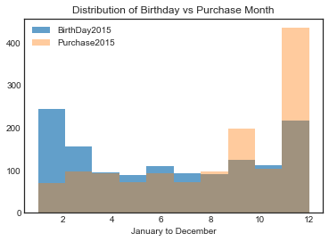

```python
# Histogram of income by gender
plt.hist('Customer_BirthDay_Month', data=new_Customer_Txn_Data[new_Customer_Txn_Data['Bill_Year'] == 2015], alpha=0.7, label='BirthDay2015');
plt.hist('Bill_Month', data=new_Customer_Txn_Data[new_Customer_Txn_Data['Bill_Year'] == 2015], alpha=0.4, label='Purchase2015');
plt.title('Distribution of Birthday vs Purchase Month');
plt.xlabel('January to December');
plt.legend();
```

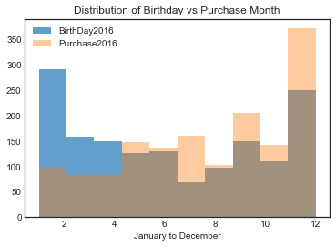

```python
# Histogram of income by gender
plt.hist('Customer_BirthDay_Month', data=new_Customer_Txn_Data[new_Customer_Txn_Data['Bill_Year'] == 2016], alpha=0.7, label='BirthDay2016');
plt.hist('Bill_Month', data=new_Customer_Txn_Data[new_Customer_Txn_Data['Bill_Year'] == 2016], alpha=0.4, label='Purchase2016');
plt.title('Distribution of Birthday vs Purchase Month');
plt.xlabel('January to December');
plt.legend();
```

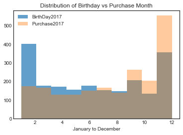

```python
# Histogram of income by gender
plt.hist('Customer_BirthDay_Month', data=new_Customer_Txn_Data[new_Customer_Txn_Data['Bill_Year'] == 2017], alpha=0.7, label='BirthDay2017');
plt.hist('Bill_Month', data=new_Customer_Txn_Data[new_Customer_Txn_Data['Bill_Year'] == 2017], alpha=0.4, label='Purchase2017');
plt.title('Distribution of Birthday vs Purchase Month');
plt.xlabel('January to December');
plt.legend();
```

### Look out for Customers who buy more in DECEMBER.

```python
# Filtering Customer who purchased in December
Dec_Shoppers = new_Customer_Txn_Data[new_Customer_Txn_Data['Bill_Month'] == 12].sort_values(by = ['Bill_Year']).loc[:,['CustomerID','BillDate','ProductCategory','Sales','Quantity']]
        #,'','','']]
```

```python
Dec_Shoppers.CustomerID.unique()
#Train :  1362 out of 2379 total Customers ==> 57% Customres shop in Dec
# TEst : 271 /500
```

```
[C21461, C21371, C21260, C21470, C21257, ..., C21492, C21253, C21372, C21197, C21496]
Length: 271
Categories (271, object): [C21461, C21371, C21260, C21470, ..., C21253, C21372, C21197, C21496]
```

### Looking @ records grouped by Customer Id

```python
GroupedByCustID = new_Customer_Txn_Data.groupby(['CustomerID', 'Bill_Year', 'Bill_Month'], axis=0)

#GroupedByCustID.groups

#for name,group in GroupedByCustID:
#    print(name)
#    print(group)
```

```python
MonthlyAggregatedSales = GroupedByCustID['Sales'].agg(np.sum)
```

```python
AggregatedMonthlyCustExpenseDF = pd.DataFrame(MonthlyAggregatedSales, dtype=np.int32)
```

```python
# Total Expenditure by a customer - year wise:
GroupedByCustID_2 = new_Customer_Txn_Data.groupby(['CustomerID', 'Bill_Year'], axis=0)
YearlyAggregatedSales = GroupedByCustID_2['Sales'].agg(np.sum)
YearlyAggregatedSalesDF = pd.DataFrame(YearlyAggregatedSales, dtype=np.int32)
YearlyAggregatedSalesDF.head()
```

| CustomerID | Bill_Year | Sales |
| --- | --- | --- |
| C21116 | 2014 | 34 |
|  | 2015 | 574 |
|  | 2017 | 4150 |
| C21117 | 2014 | 354 |
|  | 2016 | 121 |

# ------------------------------------------------------------------------------------------------------------

## High Spending Customers Retrieved :

```python
# MAximum Sale Amount = 22638.480000
```

```python
YearlyAggregatedSalesDF.sort_values(by=['Sales'], ascending=False).head()
```

| CustomerID | Bill_Year | Sales |
| --- | --- | --- |
| C21555 | 2014 | 23661 |
| C21569 | 2014 | 23661 |
| C21559 | 2017 | 13723 |
| C21395 | 2014 | 12876 |
| C21557 | 2017 | 10522 |

```python
YearlyAggregatedSalesDF.loc['C21555']   # Very Infrequenct Customer and exact copy of customer : C14696 from training data!
```

| Bill_Year | Sales |
| --- | --- |
| 2014 | 23661 |
| 2015 | 847 |
| 2017 | 534 |

## When did these biggest sales happen ?

```python
YearlyAggregatedSalesDF[(YearlyAggregatedSalesDF['Sales'] == 23661) | (YearlyAggregatedSalesDF['Sales'] == 18344)]
```

| CustomerID | Bill_Year | Sales |
| --- | --- | --- |
| C21555 | 2014 | 23661 |
| C21569 | 2014 | 23661 |

# --------------------------------------------------------------------------------------------------------------

```python
# Total Expenditure by a customer - In the given TRAIN DATA:
GroupedByCustID_3 = new_Customer_Txn_Data.groupby(['CustomerID'], axis=0)
TotalAggregatedSales = GroupedByCustID_3['Sales'].agg(np.sum)
TotalAggregatedSalesDF = pd.DataFrame(TotalAggregatedSales, dtype=np.int32)
```

```python
TotalAggregatedSales.count()    # == Total No of Customers, so correct!
TotalAggregatedSalesDF.shape
```

```
(500, 1)
```

```python
new_Customer_Txn_Data.sort_values(by=['Sales'], ascending=False).head()
```

|  | CustomerID | DOB | gender | MaritalStatus | Familysize | BillNumber | BillDate | ProductID | ProductCategory | Sales | Quantity | Customer_BirthDay_Month | Bill_Year | Bill_Month | Bill_Day | Bill_Week_of_Year | Customer_Age | Product_Unit_Price |
| --- | --- | --- | --- | --- | --- | --- | --- | --- | --- | --- | --- | --- | --- | --- | --- | --- | --- | --- |
| 5424 | C21555 | 1974-11-22 | F | Yes | 4 | B38105 | 2014-03-18 | PR7754 | Technology | 22638.480 | 6 | 11 | 2014 | 3 | 18 | 12 | 44 | 3773.080 |
| 5655 | C21569 | 1976-03-26 | M | Yes | 4 | B43114 | 2014-03-18 | PR7754 | Technology | 22638.480 | 6 | 3 | 2014 | 3 | 18 | 12 | 43 | 3773.080 |
| 5503 | C21559 | 1973-09-14 | F | Yes | 4 | B35900 | 2017-10-22 | PR7726 | Technology | 11199.968 | 4 | 9 | 2017 | 10 | 22 | 42 | 45 | 2799.992 |
| 5477 | C21557 | 1973-06-16 | F | Yes | 4 | B46695 | 2017-11-17 | PR7726 | Technology | 10499.970 | 3 | 6 | 2017 | 11 | 17 | 46 | 45 | 3499.990 |
| 3286 | C21379 | 1996-02-09 | F | Yes | 3 | B44536 | 2016-12-17 | PR6769 | Office Supplies | 9892.740 | 13 | 2 | 2016 | 12 | 17 | 50 | 23 | 760.980 |

### The most costly bought item is of category : Technology : $22638.480

## Total Sales in a year

```python
# Total Expenditure by a customer - year wise:
GroupedByYear = new_Customer_Txn_Data.groupby(['Bill_Year'], axis=0)
TotalYearlySales = GroupedByYear['Sales'].agg(np.sum)
TotalYearlySalesDF = pd.DataFrame(TotalYearlySales, dtype=np.int32)
TotalYearlySalesDF.sort_values(ascending=False, by=['Sales'])
```

| Bill_Year | Sales |
| --- | --- |
| 2017 | 437442 |
| 2016 | 352782 |
| 2014 | 334872 |
| 2015 | 272469 |

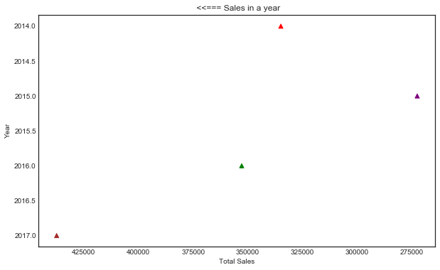

```python
# Plotting Customer BirthDay Month and His Purchase month for each record:
plt.figure(figsize = (10,6))   # How big is the plot ~ overall scale
# Scatter Plot
plt.scatter(TotalYearlySalesDF['Sales'],
            TotalYearlySalesDF.index.values,
            c = ['Red', 'purple','Green', 'Brown'],
           marker = '^')
plt.title(' <<=== Sales in a year')
plt.xlabel('Total Sales')
plt.ylabel('Year')
plt.Circle
plt.gca().invert_xaxis()
plt.gca().invert_yaxis()
#plt.xlim(0, 36)  # Tells the lenght of X-Axis
#plt.ylim(0, 36)   # Tells the lenght of Y-Axis
```

```python
# Analysis - Customer Segmentation
```

## RFM Score Calculations :

#### So that we can segment customers present in testData for testing our solution. The test data customers also belong to 14-17 period.

#### Step 1. Aggregate records group by customer - for evaluating RFM values

```python
Customer_Transactions = pd.merge(new_Customers, new_Customers_Txns, on='CustomerID')
Customer_Transactions.head(2)
```

|  | CustomerID | DOB | gender | MaritalStatus | Familysize | BillNumber | BillDate | ProductID | ProductCategory | Sales | Quantity |
| --- | --- | --- | --- | --- | --- | --- | --- | --- | --- | --- | --- |
| 0 | C21116 | 1973-11-21 | M | Yes | 4 | B38262 | 2014-09-19 | PR7012 | Office Supplies | 5.67 | 3 |
| 1 | C21116 | 1973-11-21 | M | Yes | 4 | B38128 | 2014-09-23 | PR7313 | Office Supplies | 28.80 | 9 |

```python
Customer_Transactions['DOB'] = pd.to_datetime(Customer_Transactions['DOB'])
Customer_Transactions['BillDate'] = pd.to_datetime(Customer_Transactions['BillDate'])
```

```python
Customer_Transactions.drop(['gender','MaritalStatus','Familysize','ProductID','ProductCategory'], axis=1, inplace=True)
```

```python
Customer_Transactions.info()
```

```
<class 'pandas.core.frame.DataFrame'>
Int64Index: 6220 entries, 0 to 6219
Data columns (total 6 columns):
CustomerID    6220 non-null category
DOB           6220 non-null datetime64[ns]
BillNumber    6220 non-null category
BillDate      6220 non-null datetime64[ns]
Sales         6220 non-null float64
Quantity      6220 non-null int64
dtypes: category(2), datetime64[ns](2), float64(1), int64(1)
memory usage: 395.5 KB
```

```python
GroupedByCustomer_ID = Customer_Transactions.groupby(['CustomerID'], axis=0)
GroupedByCustomer_ID
```

```
<pandas.core.groupby.groupby.DataFrameGroupBy object at 0x000002A83F0959B0>
```

###### Record Aggregation Complete..

#### Step 2. Get Most Recent Visit Date of each customer post aggregation

```python
# Function that takes a list of dates and returns the most recent date.
def _getMostRecent_Date(listOfDates):
    sorted_list = sorted(listOfDates)
    most_recent_date = sorted_list.pop()
    datetimeObject = pd.to_datetime(most_recent_date[0].astype(datetime))
    return datetimeObject.date().strftime('%m/%d/%Y')

# Fn : _getMostRecent_Date([..]) Ends
d = pd.to_datetime(datetime(2017, 10, 20))
```

```python
customer_recency = []
for name, group in GroupedByCustomer_ID:
    customer_recency.append((name, _getMostRecent_Date(group.loc[:,['BillDate']].values)))

len(customer_recency)
```

```
500
```

```python
customer_recency_DF = pd.DataFrame(data=customer_recency, columns=['Customer_ID', 'Most_Recent_Visit_Date'])
customer_recency_DF.head(2)
```

|  | Customer_ID | Most_Recent_Visit_Date |
| --- | --- | --- |
| 0 | C21116 | 07/03/2017 |
| 1 | C21117 | 09/16/2016 |

```python
customer_recency_DF['Most_Recent_Visit_Date'] = pd.to_datetime(customer_recency_DF['Most_Recent_Visit_Date'])
customer_recency_DF.dtypes
```

```
Customer_ID                       object
Most_Recent_Visit_Date    datetime64[ns]
dtype: object
```

##### >> Evaluating Recency Value of Customer

```python
# Function for Date Difference
def _diff_Dates(date1,date2):
    # Since the value stored in dataset is timestamp :
    # type(customer_recency_DF.iloc[0,1]) is ::"pandas._libs.tslibs.timestamps.Timestamp"

    #Fetching Date from the Timestamp object
    dateFromTimestamp = date2.date()

    return (date1 - dateFromTimestamp).days
```

```python
# Setting Current DATE :
current_Date = datetime.now().date()
# .strptime('%m/%d/%Y')

# Creating New Column : Recency Value:
customer_recency_DF['Customer_Recency_Value(R)'] = customer_recency_DF['Most_Recent_Visit_Date'].apply(lambda x : _diff_Dates(current_Date, x))

customer_recency_DF.head()
```

|  | Customer_ID | Most_Recent_Visit_Date | Customer_Recency_Value(R) |
| --- | --- | --- | --- |
| 0 | C21116 | 2017-07-03 | 634 |
| 1 | C21117 | 2016-09-16 | 924 |
| 2 | C21118 | 2017-12-02 | 482 |
| 3 | C21119 | 2017-11-19 | 495 |
| 4 | C21120 | 2017-05-18 | 680 |

```python
customer_recency_DF.dtypes
```

```
Customer_ID                          object
Most_Recent_Visit_Date       datetime64[ns]
Customer_Recency_Value(R)             int64
dtype: object
```

```
#### Recency Value Evaluation Completed.  <<
```

```python
# Creating New DataFrame for RFM values per Customer
Customer_RFM_DF = customer_recency_DF.copy(deep=True)
Customer_RFM_DF.shape
```

```
(500, 3)
```

#### Step 3. Get Visiting-Frequency of each customer.

```python
# Count number of records in DF created post-aggregation by customer : [ GroupedByCustomer_ID ]
```

```python
# User-Defined function to get count of customer transaction in each group:
def get_count(values):
    return len(values)
```

```python
GroupedByCustomer_ID
```

```
<pandas.core.groupby.groupby.DataFrameGroupBy object at 0x000002A83F0959B0>
```

```python
visiting_Freq = GroupedByCustomer_ID.BillDate.agg(get_count)
type(visiting_Freq)
```

```
pandas.core.series.Series
```

```python
Customer_RFM_DF.head(1)
```

|  | Customer_ID | Most_Recent_Visit_Date | Customer_Recency_Value(R) |
| --- | --- | --- | --- |
| 0 | C21116 | 2017-07-03 | 634 |

```python
Customer_RFM_DF['Visiting_Frequency(F)'] = Customer_RFM_DF['Customer_ID'].apply(lambda x : visiting_Freq[x])
Customer_RFM_DF.head()
```

|  | Customer_ID | Most_Recent_Visit_Date | Customer_Recency_Value(R) | Visiting_Frequency(F) |
| --- | --- | --- | --- | --- |
| 0 | C21116 | 2017-07-03 | 634 | 12 |
| 1 | C21117 | 2016-09-16 | 924 | 4 |
| 2 | C21118 | 2017-12-02 | 482 | 9 |
| 3 | C21119 | 2017-11-19 | 495 | 12 |
| 4 | C21120 | 2017-05-18 | 680 | 12 |

#### Step 4. Get Total Expenditure of each customer.

```python
# Total Expenditure by a customer - In the given TRAIN DATA:
GroupedByCustomer_ID
TotalAggregatedSales = GroupedByCustomer_ID['Sales'].agg(np.sum)
```

```python
Customer_RFM_DF['Total_Spending(M)'] = Customer_RFM_DF['Customer_ID'].apply(lambda x : TotalAggregatedSales[x])
Customer_RFM_DF.head()
```

|  | Customer_ID | Most_Recent_Visit_Date | Customer_Recency_Value(R) | Visiting_Frequency(F) | Total_Spending(M) |
| --- | --- | --- | --- | --- | --- |
| 0 | C21116 | 2017-07-03 | 634 | 12 | 4760.434 |
| 1 | C21117 | 2016-09-16 | 924 | 4 | 475.900 |
| 2 | C21118 | 2017-12-02 | 482 | 9 | 2189.019 |
| 3 | C21119 | 2017-11-19 | 495 | 12 | 966.710 |
| 4 | C21120 | 2017-05-18 | 680 | 12 | 974.782 |

### RFM Evaluation Completed <<<.

# **

## Will now See Distribution of RFM values for our data in order to identify scoring logic for each R,F,M value.

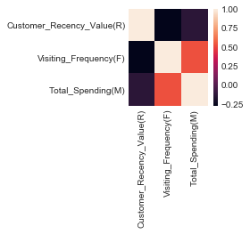

```python
plt.figure(figsize= (2,2))
sns.heatmap(Customer_RFM_DF.corr())
plt.show()
```

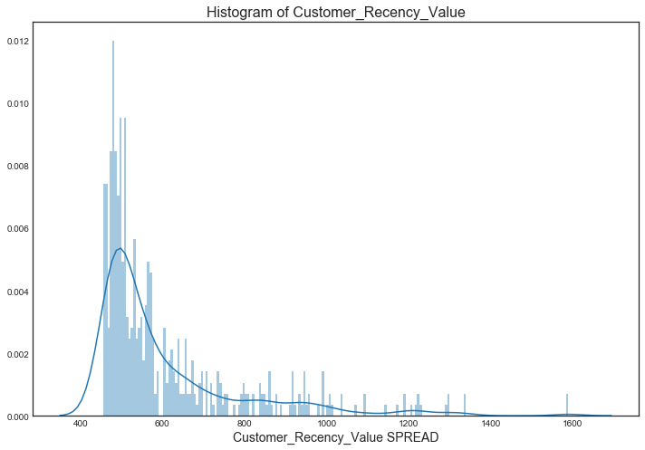

```python
plt.figure(figsize = (12,8))
b = sns.distplot(Customer_RFM_DF['Customer_Recency_Value(R)'], bins=200)
b.set_title('Histogram of Customer_Recency_Value',fontsize = 16)
b.set_xlabel("Customer_Recency_Value SPREAD",fontsize=14)
plt.show()
```

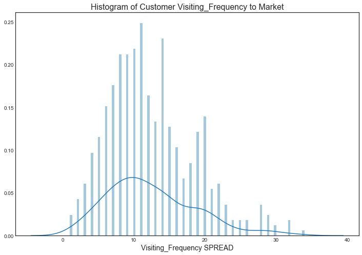

```python
plt.figure(figsize = (12,8))
b = sns.distplot(Customer_RFM_DF['Visiting_Frequency(F)'], bins=100)
b.set_title('Histogram of Customer Visiting_Frequency to Market',fontsize = 16)
b.set_xlabel("Visiting_Frequency SPREAD",fontsize=14)
plt.show()
```

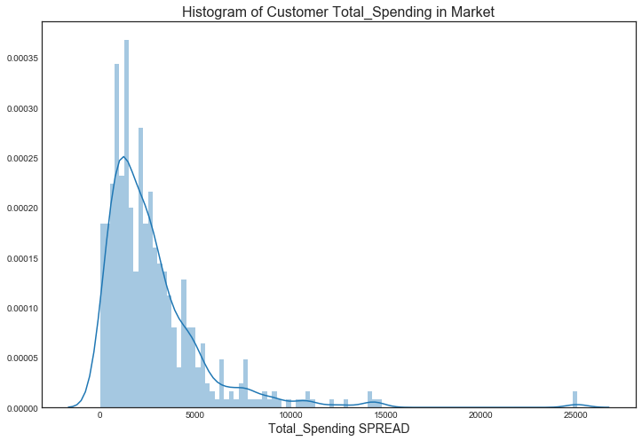

```python
plt.figure(figsize = (12,8))
b = sns.distplot(Customer_RFM_DF['Total_Spending(M)'], bins=100)
b.set_title('Histogram of Customer Total_Spending in Market',fontsize = 16)
b.set_xlabel("Total_Spending SPREAD",fontsize=14)
plt.show()
```

```python
Customer_RFM_DF.dtypes
```

```
Customer_ID                          object
Most_Recent_Visit_Date       datetime64[ns]
Customer_Recency_Value(R)             int64
Visiting_Frequency(F)                 int64
Total_Spending(M)                   float64
dtype: object
```

#### ** Descriptive Stats : RFM

```python
Customer_RFM_DF.describe()
```

|  | Customer_Recency_Value(R) | Visiting_Frequency(F) | Total_Spending(M) |
| --- | --- | --- | --- |
| count | 500.00000 | 500.000000 | 500.000000 |
| mean | 605.82400 | 12.440000 | 2795.130496 |
| std | 187.18571 | 6.236681 | 2784.148477 |
| min | 455.00000 | 1.000000 | 4.833000 |
| 25% | 488.00000 | 8.000000 | 1058.108000 |
| 50% | 530.50000 | 11.000000 | 2171.826500 |
| 75% | 642.25000 | 16.000000 | 3517.674000 |
| max | 1589.00000 | 34.000000 | 25043.050000 |

```python
# RFM Score Evaluation
```

```python
def _monetory_Score(customer_M_Value):
    if customer_M_Value <= 200:
        val = 1
    elif customer_M_Value > 200 and customer_M_Value <= 1147:
        val = 2
    elif customer_M_Value > 1147 and customer_M_Value <= 2257:
        val = 3
    elif customer_M_Value > 2257 and customer_M_Value <= 3786:
        val = 4
    else:
        val = 5
    return val
```

```python
def _frequency_Score(customer_F_Value):
    if customer_F_Value <= 6:
        val = 1
    elif customer_F_Value > 6 and customer_F_Value <= 15:
        val = 2
    elif customer_F_Value > 16 and customer_F_Value <= 22:
        val = 3
    elif customer_F_Value > 22 and customer_F_Value <= 30:
        val = 4
    else:
        val = 5
    return val
```

```python
def _recency_Score(customer_R_Value):
    if customer_R_Value <= 479:
        val = 5
    elif customer_R_Value > 479 and customer_R_Value <= 500:
        val = 4
    elif customer_R_Value > 500 and customer_R_Value <= 524:
        val = 3
    elif customer_R_Value > 524 and customer_R_Value <= 632:
        val = 2
    else:
        val = 1
    return val
```

```python
# Customer_Recency_Value(R)	Visiting_Frequency(F)	Total_Spending(M)

Customer_RFM_DF['R_Score'] = Customer_RFM_DF['Customer_Recency_Value(R)'].apply(lambda x : _recency_Score(x))
Customer_RFM_DF.head()
```

|  | Customer_ID | Most_Recent_Visit_Date | Customer_Recency_Value(R) | Visiting_Frequency(F) | Total_Spending(M) | R_Score |
| --- | --- | --- | --- | --- | --- | --- |
| 0 | C21116 | 2017-07-03 | 634 | 12 | 4760.434 | 1 |
| 1 | C21117 | 2016-09-16 | 924 | 4 | 475.900 | 1 |
| 2 | C21118 | 2017-12-02 | 482 | 9 | 2189.019 | 4 |
| 3 | C21119 | 2017-11-19 | 495 | 12 | 966.710 | 4 |
| 4 | C21120 | 2017-05-18 | 680 | 12 | 974.782 | 1 |

```python
# Customer_Recency_Value(R)	Visiting_Frequency(F)	Total_Spending(M)

Customer_RFM_DF['F_Score'] = Customer_RFM_DF['Visiting_Frequency(F)'].apply(lambda x : _frequency_Score(x))
Customer_RFM_DF.head()
```

|  | Customer_ID | Most_Recent_Visit_Date | Customer_Recency_Value(R) | Visiting_Frequency(F) | Total_Spending(M) | R_Score | F_Score |
| --- | --- | --- | --- | --- | --- | --- | --- |
| 0 | C21116 | 2017-07-03 | 634 | 12 | 4760.434 | 1 | 2 |
| 1 | C21117 | 2016-09-16 | 924 | 4 | 475.900 | 1 | 1 |
| 2 | C21118 | 2017-12-02 | 482 | 9 | 2189.019 | 4 | 2 |
| 3 | C21119 | 2017-11-19 | 495 | 12 | 966.710 | 4 | 2 |
| 4 | C21120 | 2017-05-18 | 680 | 12 | 974.782 | 1 | 2 |

```python
# Customer_Recency_Value(R)	Visiting_Frequency(F)	Total_Spending(M)

Customer_RFM_DF['M_Score'] = Customer_RFM_DF['Total_Spending(M)'].apply(lambda x : _monetory_Score(x))
Customer_RFM_DF.head()
```

|  | Customer_ID | Most_Recent_Visit_Date | Customer_Recency_Value(R) | Visiting_Frequency(F) | Total_Spending(M) | R_Score | F_Score | M_Score |
| --- | --- | --- | --- | --- | --- | --- | --- | --- |
| 0 | C21116 | 2017-07-03 | 634 | 12 | 4760.434 | 1 | 2 | 5 |
| 1 | C21117 | 2016-09-16 | 924 | 4 | 475.900 | 1 | 1 | 2 |
| 2 | C21118 | 2017-12-02 | 482 | 9 | 2189.019 | 4 | 2 | 3 |
| 3 | C21119 | 2017-11-19 | 495 | 12 | 966.710 | 4 | 2 | 2 |
| 4 | C21120 | 2017-05-18 | 680 | 12 | 974.782 | 1 | 2 | 2 |

```python
# Customer_Recency_Value(R)	Visiting_Frequency(F)	Total_Spending(M)

Customer_RFM_DF['RFM_Score'] = Customer_RFM_DF.apply(lambda x:'{:d}{:d}{:d}'.format(x['R_Score'],x['F_Score'],x['M_Score']),axis=1)
Customer_RFM_DF.head()
```

|  | Customer_ID | Most_Recent_Visit_Date | Customer_Recency_Value(R) | Visiting_Frequency(F) | Total_Spending(M) | R_Score | F_Score | M_Score | RFM_Score |
| --- | --- | --- | --- | --- | --- | --- | --- | --- | --- |
| 0 | C21116 | 2017-07-03 | 634 | 12 | 4760.434 | 1 | 2 | 5 | 125 |
| 1 | C21117 | 2016-09-16 | 924 | 4 | 475.900 | 1 | 1 | 2 | 112 |
| 2 | C21118 | 2017-12-02 | 482 | 9 | 2189.019 | 4 | 2 | 3 | 423 |
| 3 | C21119 | 2017-11-19 | 495 | 12 | 966.710 | 4 | 2 | 2 | 422 |
| 4 | C21120 | 2017-05-18 | 680 | 12 | 974.782 | 1 | 2 | 2 | 122 |

```python
Customer_RFM_DF['RFM_Score'] = Customer_RFM_DF['RFM_Score'].astype('int32')
```

```python
Customer_RFM_DF.dtypes
```

```
Customer_ID                          object
Most_Recent_Visit_Date       datetime64[ns]
Customer_Recency_Value(R)             int64
Visiting_Frequency(F)                 int64
Total_Spending(M)                   float64
R_Score                               int64
F_Score                               int64
M_Score                               int64
RFM_Score                             int32
dtype: object
```

### Sorting the Dataframe : Customer_RFM_DF on RFM_Score to see the valuable customers

### 555 : Most Valuable customer

```python
Customer_RFM_DF.sort_values(['RFM_Score'], ascending=False).head()
```

|  | Customer_ID | Most_Recent_Visit_Date | Customer_Recency_Value(R) | Visiting_Frequency(F) | Total_Spending(M) | R_Score | F_Score | M_Score | RFM_Score |
| --- | --- | --- | --- | --- | --- | --- | --- | --- | --- |
| 228 | C21344 | 2017-12-09 | 475 | 34 | 9799.923 | 5 | 5 | 5 | 555 |
| 197 | C21313 | 2017-12-11 | 473 | 16 | 2663.086 | 5 | 5 | 4 | 554 |
| 284 | C21400 | 2017-12-23 | 461 | 16 | 1791.605 | 5 | 5 | 3 | 553 |
| 97 | C21213 | 2017-12-21 | 463 | 23 | 4715.466 | 5 | 4 | 5 | 545 |
| 433 | C21549 | 2017-12-08 | 476 | 23 | 5952.859 | 5 | 4 | 5 | 545 |

```python
unique_rfm_score_arr = np.sort(pd.unique(Customer_RFM_DF['RFM_Score']))
```

```python
len(pd.unique(Customer_RFM_DF['RFM_Score']))
```

```
69
```

## Inference:

[output not shown]

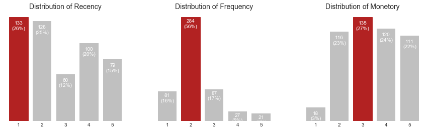

```python
# plot the distribution of customers over R, F and M
fig, axes = plt.subplots(nrows=1, ncols=3, figsize=(15, 4))

for i, p in enumerate(['R_Score', 'F_Score', 'M_Score']):
    parameters = {'R_Score':'Recency', 'F_Score':'Frequency', 'M_Score':'Monetory'}
    y = Customer_RFM_DF[p].value_counts().sort_index()
    x = y.index
    ax = axes[i]
    bars = ax.bar(x, y, color='silver')
    ax.set_frame_on(False)
    ax.tick_params(left=False, labelleft=False, bottom=False)
    ax.set_title('Distribution of {}'.format(parameters[p]),
                fontsize=14)
    for bar in bars:
        value = bar.get_height()
        if value == y.max():
            bar.set_color('firebrick')
        ax.text(bar.get_x() + bar.get_width() / 2,
                value - 5,
                '{}\n({}%)'.format(int(value), int(value * 100 / y.sum())),
               ha='center',
               va='top',
               color='w')

plt.show()
```

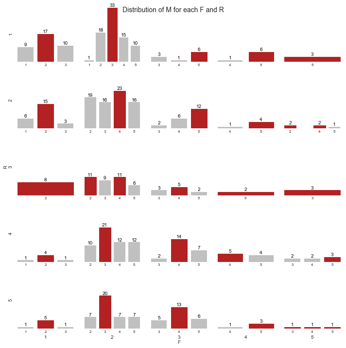

```python
# plot the distribution of M for RF score
fig, axes = plt.subplots(nrows=5, ncols=5,
                         sharex=False, sharey=True,
                         figsize=(10, 10))

r_range = range(1, 6)
f_range = range(1, 6)
for r in r_range:
    for f in f_range:
        y = Customer_RFM_DF[(Customer_RFM_DF['R_Score'] == r) & (Customer_RFM_DF['F_Score'] == f)]['M_Score'].value_counts().sort_index()
        x = y.index
        ax = axes[r - 1, f - 1]
        bars = ax.bar(x, y, color='silver')
        if r == 5:
            if f == 3:
                ax.set_xlabel('{}\nF'.format(f), va='top')
            else:
                ax.set_xlabel('{}\n'.format(f), va='top')
        if f == 1:
            if r == 3:
                ax.set_ylabel('R\n{}'.format(r))
            else:
                ax.set_ylabel(r)
        ax.set_frame_on(False)
        ax.tick_params(left=False, labelleft=False, bottom=False)
        ax.set_xticks(x)
        ax.set_xticklabels(x, fontsize=8)

        for bar in bars:
            value = bar.get_height()
            if value == y.max():
                bar.set_color('firebrick')
            ax.text(bar.get_x() + bar.get_width() / 2,
                    value,
                    int(value),
                    ha='center',
                    va='bottom',
                    color='k')
fig.suptitle('Distribution of M for each F and R', fontsize=14)
plt.tight_layout()
plt.show()
```

```python
segt_map = {
    r'[1-2][1-2][1-2]': 'hibernating',
    r'[1-2][1-5][3-5]': 'at risk',
    r'[1-2][4-5][4-5]': 'can\'t loose',
    r'3[1-2][1-2]': 'about to sleep',
    r'[2-3][2-3][2-3]': 'need attention',
    r'[2-5][3-5][3-5]': 'loyal customers',
    r'[3-4][1-2][1-2]': 'promising',
    r'[4-5]1[1-2]': 'new customers',
    r'[3-5][2-4][2-4]': 'potential loyalists',
    r'[3-5][1-2][3-5]': 'Recent & Good Purchases and New',
    r'[3-5][3-4][3-5]': 'potential Champions',
    r'[4-5][4-5][4-5]': 'champions',
    r'[1-2][3-5][1-2]': 'OLD Low Price Shoppers',
    r'[4-5][3-5][1-2]': 'New Low Price Shoppers',
}

Customer_RFM_DF['Segment'] = Customer_RFM_DF['R_Score'].map(str) + Customer_RFM_DF['F_Score'].map(str) + Customer_RFM_DF['M_Score'].map(str)
Customer_RFM_DF['Segment'] = Customer_RFM_DF['Segment'].replace(segt_map, regex=True)
Customer_RFM_DF.head()
```

|  | Customer_ID | Most_Recent_Visit_Date | Customer_Recency_Value(R) | Visiting_Frequency(F) | Total_Spending(M) | R_Score | F_Score | M_Score | RFM_Score | Segment |
| --- | --- | --- | --- | --- | --- | --- | --- | --- | --- | --- |
| 0 | C21116 | 2017-07-03 | 634 | 12 | 4760.434 | 1 | 2 | 5 | 125 | at risk |
| 1 | C21117 | 2016-09-16 | 924 | 4 | 475.900 | 1 | 1 | 2 | 112 | hibernating |
| 2 | C21118 | 2017-12-02 | 482 | 9 | 2189.019 | 4 | 2 | 3 | 423 | potential loyalists |
| 3 | C21119 | 2017-11-19 | 495 | 12 | 966.710 | 4 | 2 | 2 | 422 | promising |
| 4 | C21120 | 2017-05-18 | 680 | 12 | 974.782 | 1 | 2 | 2 | 122 | hibernating |

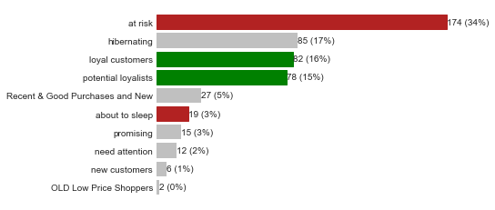

```python
# count the number of customers in each segment Created from FRM Score
segments_counts = Customer_RFM_DF['Segment'].value_counts().sort_values(ascending=True)

fig, ax = plt.subplots()

bars = ax.barh(range(len(segments_counts)),
              segments_counts,
              color='silver')
ax.set_frame_on(False)
ax.tick_params(left=False,
               bottom=False,
               labelbottom=False)
ax.set_yticks(range(len(segments_counts)))
ax.set_yticklabels(segments_counts.index)

for i, bar in enumerate(bars):
        value = bar.get_width()
        if segments_counts.index[i] in ['champions', 'loyal customers', 'potential loyalists', 'potential Champions']:
            bar.set_color('green')
        if segments_counts.index[i] in ['at risk', 'about to sleep']:
            bar.set_color('firebrick')
        ax.text(value,
                bar.get_y() + bar.get_height()/2,
                '{:,} ({:}%)'.format(int(value),
                                   int(value*100/segments_counts.sum())),
                va='center',
                ha='left'
               )

plt.show()
```

```python
# Get unique age values
len(pd.unique(new_Customer_Txn_Data['Customer_Age']))
```

```
68
```

```python
# Similar to RFM : Evaluate a score for Quantity purchase also:
# Total Expenditure by a customer - In the given TRAIN DATA:

# Use : GroupedByCustomer_ID
TotalAggregatedQuantities = GroupedByCustomer_ID['Quantity'].agg(np.sum)
```

```python
Customer_RFM_DF['Total_Quantities_Purchased(Q)'] = Customer_RFM_DF['Customer_ID'].apply(lambda x : TotalAggregatedQuantities[x])
Customer_RFM_DF.head()
```

|  | Customer_ID | Most_Recent_Visit_Date | Customer_Recency_Value(R) | Visiting_Frequency(F) | Total_Spending(M) | R_Score | F_Score | M_Score | RFM_Score | Segment | Total_Quantities_Purchased(Q) |
| --- | --- | --- | --- | --- | --- | --- | --- | --- | --- | --- | --- |
| 0 | C21116 | 2017-07-03 | 634 | 12 | 4760.434 | 1 | 2 | 5 | 125 | at risk | 41 |
| 1 | C21117 | 2016-09-16 | 924 | 4 | 475.900 | 1 | 1 | 2 | 112 | hibernating | 14 |
| 2 | C21118 | 2017-12-02 | 482 | 9 | 2189.019 | 4 | 2 | 3 | 423 | potential loyalists | 43 |
| 3 | C21119 | 2017-11-19 | 495 | 12 | 966.710 | 4 | 2 | 2 | 422 | promising | 37 |
| 4 | C21120 | 2017-05-18 | 680 | 12 | 974.782 | 1 | 2 | 2 | 122 | hibernating | 51 |

```python
Customer_RFM_DF.describe().transpose()
```

|  | count | mean | std | min | 25% | 50% | 75% | max |
| --- | --- | --- | --- | --- | --- | --- | --- | --- |
| Customer_Recency_Value(R) | 500.0 | 605.824000 | 187.185710 | 455.000 | 488.000 | 530.5000 | 642.250 | 1589.00 |
| Visiting_Frequency(F) | 500.0 | 12.440000 | 6.236681 | 1.000 | 8.000 | 11.0000 | 16.000 | 34.00 |
| Total_Spending(M) | 500.0 | 2795.130496 | 2784.148477 | 4.833 | 1058.108 | 2171.8265 | 3517.674 | 25043.05 |
| R_Score | 500.0 | 2.728000 | 1.442976 | 1.000 | 1.000 | 2.0000 | 4.000 | 5.00 |
| F_Score | 500.0 | 2.246000 | 0.933395 | 1.000 | 2.000 | 2.0000 | 3.000 | 5.00 |
| M_Score | 500.0 | 3.380000 | 1.167187 | 1.000 | 2.000 | 3.0000 | 4.000 | 5.00 |
| RFM_Score | 500.0 | 298.640000 | 146.783054 | 111.000 | 145.000 | 235.0000 | 425.000 | 555.00 |
| Total_Quantities_Purchased(Q) | 500.0 | 47.122000 | 25.141027 | 2.000 | 29.000 | 43.0000 | 63.000 | 150.00 |

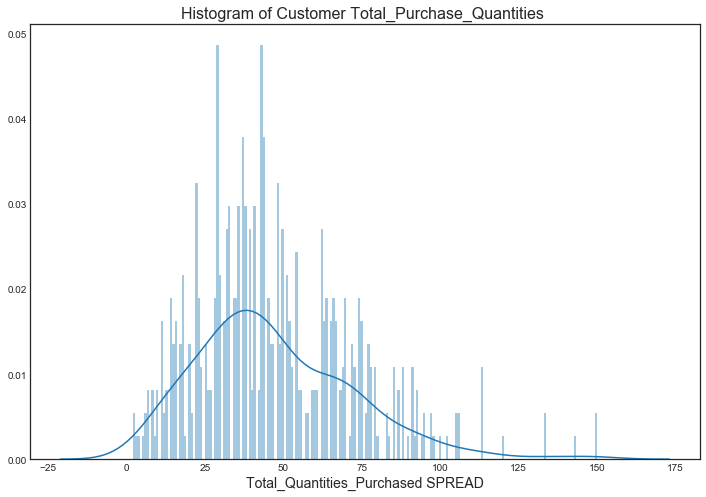

```python
plt.figure(figsize = (12,8))
b = sns.distplot(Customer_RFM_DF['Total_Quantities_Purchased(Q)'], bins=200)
b.set_title('Histogram of Customer Total_Purchase_Quantities ',fontsize = 16)
b.set_xlabel("Total_Quantities_Purchased SPREAD",fontsize=14)
plt.show()
```

```python
def _quantity_Score(customer_Q_Value):
    if customer_Q_Value <= 25:
        val = 1
    elif customer_Q_Value > 25 and customer_Q_Value <= 50:
        val = 2
    elif customer_Q_Value > 50 and customer_Q_Value <= 75:
        val = 3
    elif customer_Q_Value > 75 and customer_Q_Value <= 100:
        val = 4
    else:
        val = 5
    return val
```

```python
Customer_RFM_DF['Q_Score'] = Customer_RFM_DF['Total_Quantities_Purchased(Q)'].apply(lambda x : _quantity_Score(x))
Customer_RFM_DF.head()
```

|  | Customer_ID | Most_Recent_Visit_Date | Customer_Recency_Value(R) | Visiting_Frequency(F) | Total_Spending(M) | R_Score | F_Score | M_Score | RFM_Score | Segment | Total_Quantities_Purchased(Q) | Q_Score |
| --- | --- | --- | --- | --- | --- | --- | --- | --- | --- | --- | --- | --- |
| 0 | C21116 | 2017-07-03 | 634 | 12 | 4760.434 | 1 | 2 | 5 | 125 | at risk | 41 | 2 |
| 1 | C21117 | 2016-09-16 | 924 | 4 | 475.900 | 1 | 1 | 2 | 112 | hibernating | 14 | 1 |
| 2 | C21118 | 2017-12-02 | 482 | 9 | 2189.019 | 4 | 2 | 3 | 423 | potential loyalists | 43 | 2 |
| 3 | C21119 | 2017-11-19 | 495 | 12 | 966.710 | 4 | 2 | 2 | 422 | promising | 37 | 2 |
| 4 | C21120 | 2017-05-18 | 680 | 12 | 974.782 | 1 | 2 | 2 | 122 | hibernating | 51 | 3 |

```python
# Get unique age values
len(pd.unique(Customer_RFM_DF['Total_Quantities_Purchased(Q)']))
```

```
101
```

```python
# Creating Dataframe of categorical columns for K-mode clustering

# columns :  R_Score	F_Score 	M_Score 	gender	"Marital-Status"	Familysize	Age 	Q_Score : 8
```

```python
Customer_RFM_DF_Catg = Customer_RFM_DF.loc[:,['Customer_ID','R_Score','F_Score','M_Score','Q_Score']]
Customer_RFM_DF_Catg.shape
```

```
(500, 5)
```

```python
#Customer_RFM_DF_Catg['Customer_ID'] = Customer_RFM_DF_Catg['Customer_ID'].astype('category')
```

```python
new_Customer_Txn_Data.shape
```

```
(6220, 18)
```

```python
TEST_customer_Txn_Data_Copy = new_Customer_Txn_Data.loc[:,['CustomerID','gender','MaritalStatus','Familysize', 'Customer_Age']]
TEST_customer_Txn_Data_Copy.shape
```

```
(6220, 5)
```

```python
TEST_customer_Txn_Data_Copy = TEST_customer_Txn_Data_Copy.drop_duplicates()
TEST_customer_Txn_Data_Copy.shape
```

```
(500, 5)
```

```python
TEST_customer_Txn_Data_Copy.head(2)
```

|  | CustomerID | gender | MaritalStatus | Familysize | Customer_Age |
| --- | --- | --- | --- | --- | --- |
| 0 | C21116 | M | Yes | 4 | 45 |
| 12 | C21117 | M | Yes | 3 | 34 |

```python
TEST_customer_Txn_Data_Copy.rename(columns={'CustomerID': 'Customer_ID'}, inplace=True)
```

```python
DF_Clustering_Mix_Features = pd.merge(Customer_RFM_DF, TEST_customer_Txn_Data_Copy, on='Customer_ID')
DF_Clustering_Mix_Features.head(2)
```

|  | Customer_ID | Most_Recent_Visit_Date | Customer_Recency_Value(R) | Visiting_Frequency(F) | Total_Spending(M) | R_Score | F_Score | M_Score | RFM_Score | Segment | Total_Quantities_Purchased(Q) | Q_Score | gender | MaritalStatus | Familysize | Customer_Age |
| --- | --- | --- | --- | --- | --- | --- | --- | --- | --- | --- | --- | --- | --- | --- | --- | --- |
| 0 | C21116 | 2017-07-03 | 634 | 12 | 4760.434 | 1 | 2 | 5 | 125 | at risk | 41 | 2 | M | Yes | 4 | 45 |
| 1 | C21117 | 2016-09-16 | 924 | 4 | 475.900 | 1 | 1 | 2 | 112 | hibernating | 14 | 1 | M | Yes | 3 | 34 |

```python
DF_Clustering_Mix_Features.to_csv("TEST_DF_Clustering_Mix_Features.csv")
```

## Continue with R for Clustering Results